# Unpacking the Drivers of Volatility: An Empirical Study

# 3.4.3 Price-to-Earnings Ratio

A further financial metric under examination is the price-to-earnings (P/E) ratio, which appraises a company’s present stock price concerning its earnings per share. The calculation is achieved by dividing the current market price per share of a company’s stock (i.e., its current stock price) by its earnings per share, which is determined by dividing the net income by the outstanding share number.

Based on the graph below, it is evident that a substantial increase in the price-to-earnings ratio corresponds to a significant rise in the company’s volatility.

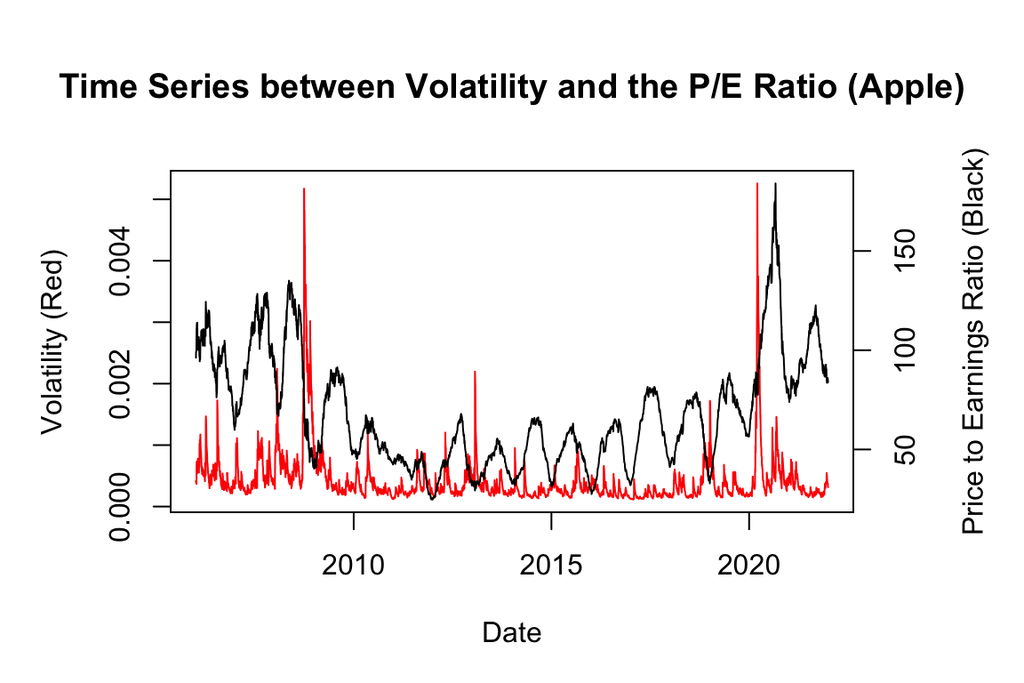

A higher P/E ratio generally suggests that investors are willing to pay more for each dollar of the company’s earnings. This can reflect investor optimism about the company’s growth potential and future earnings. Nonetheless, a higher P/E ratio can also increase the volatility of a company’s stock price. This is because a higher P/E ratio indicates that investors have high expectations for the company’s future performance. If the company’s earnings fail to meet these expectations, investors may become disappointed and start selling their shares, causing the stock price to drop. This can lead to increased volatility in the stock price.

Conversely, a lower P/E ratio generally indicates that investors are less optimistic about the company’s future performance. While this may result in a more stable stock price, it could also indicate a lack of confidence in the company’s long-term prospects.

# 4. Discussion

# 4.1 Findings

In addition to the empirical data, it is logical to understand the reasons why the inflation rate, unemployment rate, and interest rate influence the volatility of a company’s stock price.

Exploring the impact of inflation on volatility is reasonable because inflation can introduce uncertainty and instability into the market, resulting in fluctuations in prices and returns. When inflation is high, investors often become more cautious and risk-averse, leading to reduced investment levels and heightened volatility.

More information can be found at [“Inflation, Volatility and Growth” written by Ruth Judson and Athanasios Orphanides](https://www.federalreserve.gov/pubs/feds/1996/199619/199619pap.pdf)

The presence of high unemployment rates can contribute to volatility for various reasons. Firstly, it can give rise to social and political unrest, which can subsequently impact the financial markets. Furthermore, elevated unemployment rates tend to reduce consumer spending, resulting in decreased revenues and profits for businesses. This decline in economic activity can cause stock prices to decline, thus contributing to increased volatility within the stock market. Given these factors, it is reasonable to assess the potential influence of the unemployment rate on volatility.

More information can be found at [“Unanticipated Unemployment Rate News on the Stock Market” written by David Chi](https://www.econ.berkeley.edu/sites/default/files/Econ%20honor%20Thesis%20.pdf)

Considering the impact of interest rates on volatility is also logical. Lower interest rates make borrowing money cheaper and more accessible, encouraging increased investment and economic activity. However, this can also elevate the risk of market volatility, as investors may pursue riskier investments in the pursuit of higher returns. Thus, it is reasonable to acknowledge the potential impact of the interest rate on volatility.

More information can be found at [“The Impact of Interest Rate Volatility on Stock Market Development: Evidence from Emerging Markets” written by Massomeh Hajilee and Omar M. Al Nasser Chi](https://www.jstor.org/stable/pdf/26415740.pdf)

# 4.2 Limitations

However, it is important to acknowledge the limitations of the study. Like any data source, there are inherent limitations, and it is always advisable for users to conduct their own research and analysis before making economic decisions or drawing conclusions based solely on the data provided.

One notable limitation is that certain data was unavailable for all time periods. There can be various factors contributing to this issue. For instance, newer companies may have limited historical data compared to well-established companies. Additionally, some companies may choose not to disclose specific financial information due to concerns about privacy or competition. Moreover, gaps or errors in the data collection process can also result in limitations in the available data.

In fact, during the initial phases, a noticeable pattern of missing data was observed, which could be attributed to factors such as less widespread or comprehensive record-keeping practices in the past, limited technology impeding data collection and analysis, or a lack of interest in collecting or preserving certain types of data. These factors may have influenced the completeness and accuracy of the data utilized in the study.

Another limitation of the study is the inherent unpredictability of the stock market, which poses a significant challenge in making precise forecasts about future volatility and its determining factors. Additionally, the study focused on only two companies with limited yearly information available, making it difficult to thoroughly analyze the impact of total revenue and other financial factors on volatility. Consequently, further investigation is necessary to explore and understand these relationships more comprehensively.

Finally, while there may be factors that exhibit a close relationship with other factors, the available data set alone is insufficient to definitively conclude this. To establish a strong causal relationship, additional data and rigorous analysis are necessary. This includes obtaining more detailed and granular data, such as sector-specific or industry-specific information, to capture specific dynamics within the economy. Additionally, cross-country data can provide insights into the relationship’s consistency across different regions and economies. Furthermore, incorporating complementary qualitative data and employing advanced econometric techniques can help account for confounding factors and spurious correlations. By considering a broader range of data sources and employing robust analytical methods, researchers can enhance their understanding of whether these indicators truly have a significant relationship. Thus, based on this comprehensive analysis and understanding, researchers and investors would have the ability to substantiate the study’s results.

# 5. Conclusion

In summary, the empirical study uncovered a diverse range of factors that exhibited potential influence on the volatility changes. The findings of the study shed light on several variables that could potentially impact volatility, highlighting the intricate dynamics within the market. These factors encompassed a broad spectrum, including macroeconomic indicators, company-specific financial metrics, and external market conditions.

Among the macroeconomic indicators, variables such as inflation rate, unemployment rate, and interest rate were identified as potential drivers of volatility. The study revealed that fluctuations in these economic factors could introduce uncertainty and instability, consequently impacting the volatility of stock prices. Changes in inflation rates could create an environment of market uncertainty, leading to price fluctuations and altering investor behavior. Similarly, high unemployment rates were found to contribute to volatility through their association with social unrest and reduced consumer spending, adversely affecting businesses and, consequently, stock prices. Additionally, variations in interest rates were shown to influence volatility by influencing investment patterns and prompting investors to undertake riskier ventures to pursue higher returns.

In addition to macroeconomic indicators, the study examined the impact of company-specific financial metrics on volatility. It found that factors such as debt-to-equity ratio, and price-to-earnings ratio could potentially influence volatility. The debt-to-equity ratio, which represents a company’s financial leverage, was found to have a potential association with volatility. Higher levels of debt relative to equity could amplify market sensitivity and increase volatility. Additionally, variations in the price-to-earnings ratio, reflecting the market’s perception of a company’s value, were identified as potential contributors to volatility.

The comprehensive analysis conducted in the empirical study encompassed a wide array of factors that exhibited potential associations with volatility changes. However, it is important to note that further research and analysis are required to validate and refine these findings, considering the dynamic and complex nature of the stock market.

While the empirical study provided valuable insights into the potential factors influencing volatility changes, it is crucial to acknowledge that the analysis focused on a limited set of variables. The complex and ever-changing nature of the stock market suggests that there are likely additional factors that could contribute to volatility fluctuations. Therefore, future research endeavors should aim to explore and expand upon the findings by considering a more comprehensive range of factors, particularly delving deeper into the company’s financial aspects.

Examining the company’s finances in greater detail would provide deeper insights into the relationship between financial performance and stock price volatility. Factors such as profit margins, cash flow, capital structure, and liquidity could be investigated to understand their potential impact on volatility. Analyzing these financial indicators may uncover important patterns and correlations, allowing for a more nuanced understanding of how a company’s financial health influences stock price volatility.

By undertaking these endeavors, researchers can gain deeper insights into the intricate relationships within the stock market and provide more robust frameworks for understanding and predicting stock price volatility for investors.

# 6. References

Chi, David. Unanticipated Unemployment Rate News on the Stock Market. Zotero, https://www.econ.berkeley.edu/sites/default/files/Econ%20honor%20Thesis%20.pdf.

Costa, Francisco Joao Matos. Forecasting Volatility Using GARCH Models. Apr. 2017. Zotero, https://core.ac.uk/download/pdf/132797589.pdf.

Hajilee, Massomeh, and Omar M. Al Nasser. “The Impact of Interest Rate Volatility on Stock Market Development: Evidence from Emerging Markets.” The Journal of Developing Areas, vol. 51, no. 2, 2017, pp. 301–13, https://www.jstor.org/stable/pdf/26415740.pdf.

Judson, Ruth, and Athanasios Orphanides. Inflation, Volatility and Growth. May 1996. Zotero, https://www.federalreserve.gov/pubs/feds/1996/199619/199619pap.pdf.

# 7. Appendix

# 7.1 Appendix 1: Data Dictionary

# Financial Variables:

The number of missing values (NA) is shown below.

**Below are the ranges for each variable and company**

For the financial data sets, there are approximately 206 different variables, so I will concentrate on the few important ones for the study (more could possibly be examined in the future).

Date: When the entries were filed or collected. The date variable ranges from the end of 1986 to the end of 2022 (varies for each company - Apple starts at 1986 and Google starts at 2004).

Outstanding Share Number: It represents a unit of ownership in a company and typically entitle the shareholder to participate in the profits of the company through dividends and to vote on corporate matters. There is no unit for the numeric (double) variable since it is a total number.

**The following financial variables are numeric (double) and are measured in dollars**

Net Income: A financial metric that represents the amount of profit a company has earned over a specific period of time.

Total Debt: The sum of all outstanding debt that a company or individual owes to creditors, lenders or financial institutions.

Stockholders Equity: The residual claim on a company’s assets after deducting its liabilities. It represents the amount of a company’s assets that are financed by the owners rather than by creditors

**Apple’s Financial Distribution**

```
##       Date            StockholdersEquity  OrdinarySharesNumber
##  Min.   :1986-09-30   Min.   :6.941e+08   Min.   :3.308e+09
##  1st Qu.:1997-06-30   1st Qu.:2.283e+09   1st Qu.:1.417e+10
##  Median :2005-12-31   Median :8.380e+09   Median :1.941e+10
##  Mean   :2005-12-18   Mean   :4.101e+10   Mean   :1.916e+10
##  3rd Qu.:2014-06-30   3rd Qu.:7.662e+10   3rd Qu.:2.368e+10
##  Max.   :2022-12-31   Max.   :1.402e+11   Max.   :2.632e+10
##
##    TotalDebt           NetIncome
##  Min.   :6.000e+06   Min.   :-7.400e+08
##  1st Qu.:3.073e+08   1st Qu.: 9.760e+07
##  Median :9.540e+08   Median : 5.420e+08
##  Mean   :3.592e+10   Mean   : 5.429e+09
##  3rd Qu.:8.742e+10   3rd Qu.: 1.022e+10
##  Max.   :1.247e+11   Max.   : 3.463e+10
##  NA's   :39          NA's   :4
```

**Google’s Financial Distribution**

```
##       Date            StockholdersEquity  OrdinarySharesNumber
##  Min.   :2004-06-30   Min.   :1.017e+09   Min.   :6.095e+09
##  1st Qu.:2009-02-14   1st Qu.:2.904e+10   1st Qu.:1.261e+10
##  Median :2013-09-30   Median :8.299e+10   Median :1.318e+10
##  Mean   :2013-09-29   Mean   :1.017e+11   Mean   :1.296e+10
##  3rd Qu.:2018-05-15   3rd Qu.:1.614e+11   3rd Qu.:1.369e+10
##  Max.   :2022-12-31   Max.   :2.561e+11   Max.   :1.392e+10
##
##    TotalDebt           NetIncome
##  Min.   :1.000e+04   Min.   :-3.020e+09
##  1st Qu.:3.968e+09   1st Qu.: 1.299e+09
##  Median :5.234e+09   Median : 2.970e+09
##  Mean   :9.413e+09   Mean   : 4.881e+09
##  3rd Qu.:1.331e+10   3rd Qu.: 6.694e+09
##  Max.   :2.968e+10   Max.   : 2.064e+10
##  NA's   :19
```

# Stock Variables:

**Below are the ranges for each variable and company**

Date: When the entries were filed or collected. The date variable ranges from the beginning of 2006 to the end of 2021.

Volume: The total number of shares of a stock or other financial asset that have been traded during a specific period of time, usually a trading day. The numeric (double) variable is measured as a total quantity. The ranges depends on the company (volume distribution for each company will be shown below).

Inflation: A market-based measure of the rate at which the general level of prices for goods and services is increasing over time expectations for the next 10 years. The numeric (double) variable is measured as a proportion, representing the difference between the yield of a nominal 10-year Treasury bond and the yield of a 10-year Treasury inflation-protected security (TIPS).

Dollar Index: A measure of the value of the U.S. dollar relative to a basket of currencies from major U.S. trading partners. The numeric (double) variable is measured as an index, where changes in the index represent the percentage change in the dollar index.

Log Return: A financial metric that measures the relative change in the price of a security or asset over a specific period of time. It is calculated by taking the natural logarithm of the ratio of the price at the end of the period to the price at the beginning of the period.The numeric (double) variable is unit less as it is defined as the logarithmic difference between two adjusted close prices.

**The following stock variables are numeric (double) and are measured in dollars**

Adj. Close: The stock price that has been adjusted to reflect any corporate actions that may have occurred, such as stock splits, dividends, or spin-offs.

**Apple’s Stock Distribution**

```
##       Date              Adj.Close           Volume            Inflation
##  Min.   :2006-01-05   Min.   :  1.540   Min.   :4.545e+07   Min.   :0.040
##  1st Qu.:2009-12-25   1st Qu.:  6.141   1st Qu.:1.295e+08   1st Qu.:1.750
##  Median :2013-12-25   Median : 18.461   Median :2.906e+08   Median :2.100
##  Mean   :2013-12-29   Mean   : 31.376   Mean   :4.254e+08   Mean   :2.004
##  3rd Qu.:2017-12-28   3rd Qu.: 39.420   3rd Qu.:6.054e+08   3rd Qu.:2.320
##  Max.   :2021-12-30   Max.   :179.016   Max.   :3.373e+09   Max.   :2.760
##   DollarIndex       LogReturn
##  Min.   : 85.47   Min.   :-0.197470
##  1st Qu.: 92.83   1st Qu.:-0.008237
##  Median : 98.83   Median : 0.001000
##  Mean   :102.14   Mean   : 0.001097
##  3rd Qu.:112.78   3rd Qu.: 0.011798
##  Max.   :126.13   Max.   : 0.118294
```

**Google’s Stock Distribution**

```
##       Date              Adj.Close           Volume            Inflation
##  Min.   :2006-01-05   Min.   :  6.412   Min.   :1.584e+05   Min.   :0.040
##  1st Qu.:2009-12-25   1st Qu.: 13.326   1st Qu.:3.013e+07   1st Qu.:1.750
##  Median :2013-12-25   Median : 25.751   Median :6.594e+07   Median :2.100
##  Mean   :2013-12-29   Mean   : 35.447   Mean   :1.049e+08   Mean   :2.004
##  3rd Qu.:2017-12-28   3rd Qu.: 51.368   3rd Qu.:1.331e+08   3rd Qu.:2.320
##  Max.   :2021-12-30   Max.   :150.709   Max.   :1.651e+09   Max.   :2.760
##   DollarIndex       LogReturn
##  Min.   : 85.47   Min.   :-0.1234016
##  1st Qu.: 92.83   1st Qu.:-0.0071645
##  Median : 98.83   Median : 0.0006331
##  Mean   :102.14   Mean   : 0.0006499
##  3rd Qu.:112.78   3rd Qu.: 0.0092763
##  Max.   :126.13   Max.   : 0.1822511
```

# Economic Variables:

The number of missing values (NA) is shown below.

**Below are the ranges for each variable**

Date: When the entries were filed or collected. The date variable ranges from the beginning of 2005 to the end of 2021.

Interest Rate: The rate of cost of borrowing money at which eligible financial institutions can borrow money directly from the Federal Reserve. The numeric (double) variable is measured in a proportion.

Unemployment Rate: A measure of the percentage of the labor force that is currently unemployed and actively seeking employment. The numeric (double) variable is measured in a proportion.

Total Debt: The amount of money owed by the federal government of the United States to creditors. The numeric (double) variable is measured in millions of dollars.

GDP: (Gross Domestic Product) Economic indicator that measures the total value of all goods and services produced within a country’s borders in a specific period, usually a year or a quarter (quarter for the study). The numeric (double) variable is measured in billions of dollars.

```
##       Date             InterestRate   UnemploymentRate   TotalDebt
##  Min.   :2005-01-01   Min.   :0.250   Min.   : 3.500   Min.   : 60.36
##  1st Qu.:2009-02-15   1st Qu.:0.750   1st Qu.: 4.600   1st Qu.: 78.69
##  Median :2013-04-01   Median :0.750   Median : 5.400   Median : 99.77
##  Mean   :2013-04-01   Mean   :1.918   Mean   : 6.222   Mean   : 92.55
##  3rd Qu.:2017-05-16   3rd Qu.:2.625   3rd Qu.: 7.900   3rd Qu.:103.83
##  Max.   :2021-07-01   Max.   :6.250   Max.   :14.700   Max.   :134.84
##                                                        NA's   :132
##       GDP
##  Min.   :12767
##  1st Qu.:14711
##  Median :16700
##  Mean   :17221
##  3rd Qu.:19433
##  Max.   :23550
##  NA's   :132
```

# 7.2 Appendix 2: Graphical Displays for Google

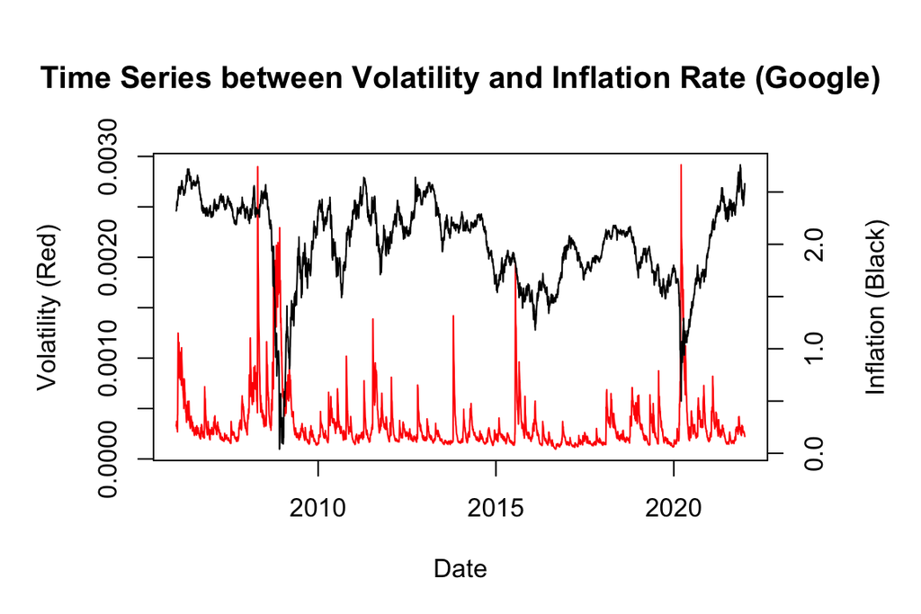

```
##
## Call:
## lm(formula = volatility ~ inflation, data = df)
##
## Residuals:
##        Min         1Q     Median         3Q        Max
## -3.571e-04 -1.564e-04 -6.574e-05  5.157e-05  2.621e-03
##
## Coefficients:
##               Estimate Std. Error t value Pr(>|t|)
## (Intercept)  7.615e-04  2.184e-05   34.87   <2e-16 ***
## inflation   -2.098e-04  1.067e-05  -19.66   <2e-16 ***
## ---
## Signif. codes:  0 '***' 0.001 '**' 0.01 '*' 0.05 '.' 0.1 ' ' 1
##
## Residual standard error: 0.0002774 on 3964 degrees of freedom
## Multiple R-squared:  0.08882,    Adjusted R-squared:  0.08859
## F-statistic: 386.4 on 1 and 3964 DF,  p-value: < 2.2e-16
```

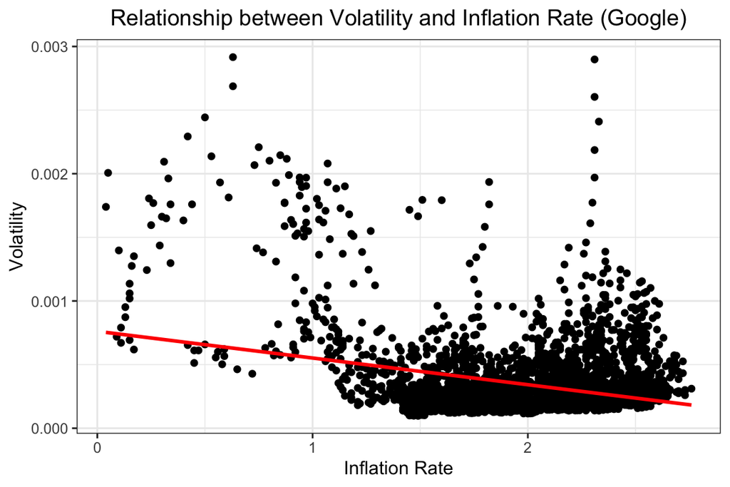

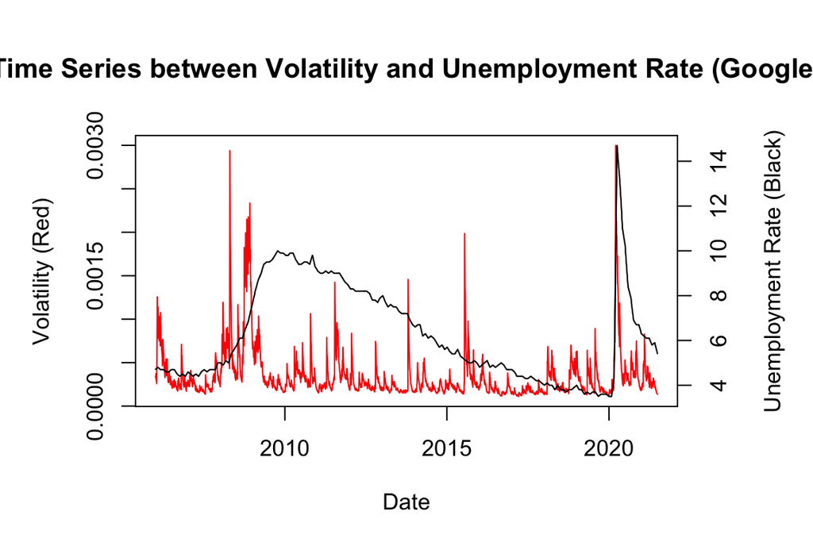

```
##
## Call:
## lm(formula = volatility ~ unemployment_rate, data = df)
##
## Residuals:
##        Min         1Q     Median         3Q        Max
## -2.870e-04 -1.496e-04 -9.064e-05  3.236e-05  2.621e-03
##
## Coefficients:
##                    Estimate Std. Error t value Pr(>|t|)
## (Intercept)       1.749e-04  1.458e-05   12.00   <2e-16 ***
## unemployment_rate 2.727e-05  2.188e-06   12.46   <2e-16 ***
## ---
## Signif. codes:  0 '***' 0.001 '**' 0.01 '*' 0.05 '.' 0.1 ' ' 1
##
## Residual standard error: 0.0002917 on 3839 degrees of freedom
## Multiple R-squared:  0.03887,    Adjusted R-squared:  0.03862
## F-statistic: 155.2 on 1 and 3839 DF,  p-value: < 2.2e-16
```

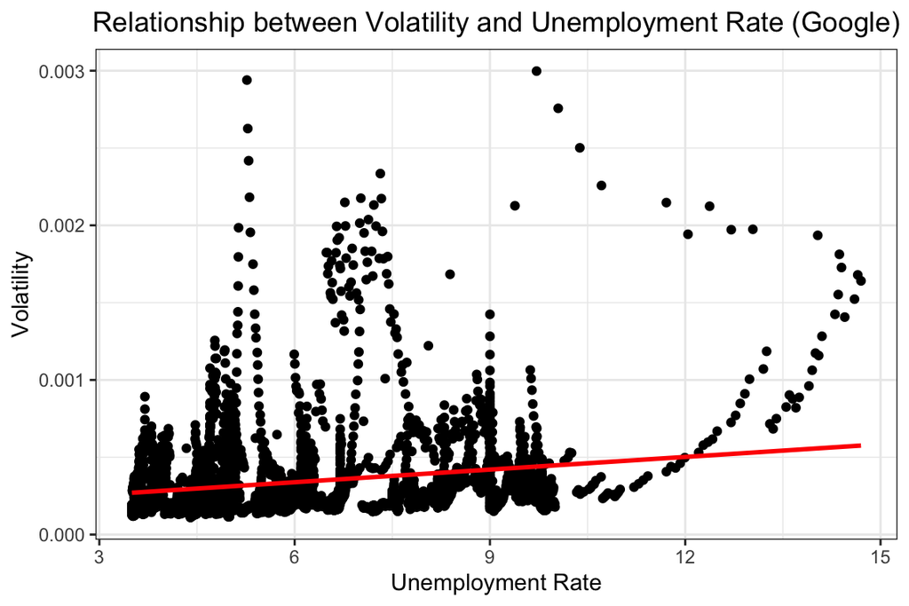

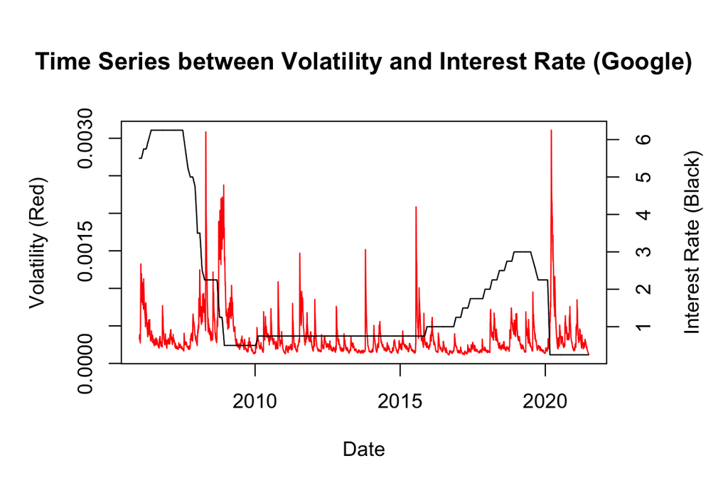

```
##
## Call:
## lm(formula = volatility ~ interest_rate, data = df)
##
## Residuals:
##        Min         1Q     Median         3Q        Max
## -2.305e-04 -1.590e-04 -9.989e-05  2.191e-05  2.763e-03
##
## Coefficients:
##                Estimate Std. Error t value Pr(>|t|)
## (Intercept)   3.426e-04  6.919e-06  49.508   <2e-16 ***
## interest_rate 3.392e-06  2.771e-06   1.224    0.221
## ---
## Signif. codes:  0 '***' 0.001 '**' 0.01 '*' 0.05 '.' 0.1 ' ' 1
##
## Residual standard error: 0.0003032 on 3839 degrees of freedom
## Multiple R-squared:  0.0003903,  Adjusted R-squared:  0.0001299
## F-statistic: 1.499 on 1 and 3839 DF,  p-value: 0.2209
```

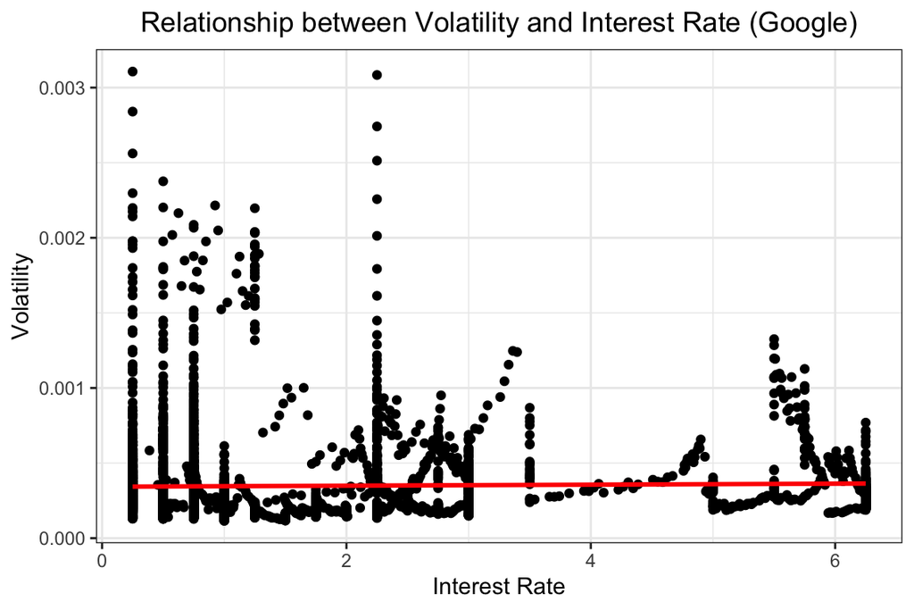

Although the GARCH model showed a similar relationship between interest rates and volatility for Google as it did for Apple, the results of the linear regression analysis were negative. In other words, there was no significant statistical evidence found to support a relationship between interest rates and Google’s stock price volatility.

A potential explanation for this disparity in the relationship between interest rates and stock price volatility between Google and Apple could be attributed to differences in their respective product offerings and corresponding consumer demand patterns. Additionally, varying macroeconomic factors such as global economic conditions and geopolitical events may impact each company differently, ultimately influencing their response to fluctuations in interest rates.

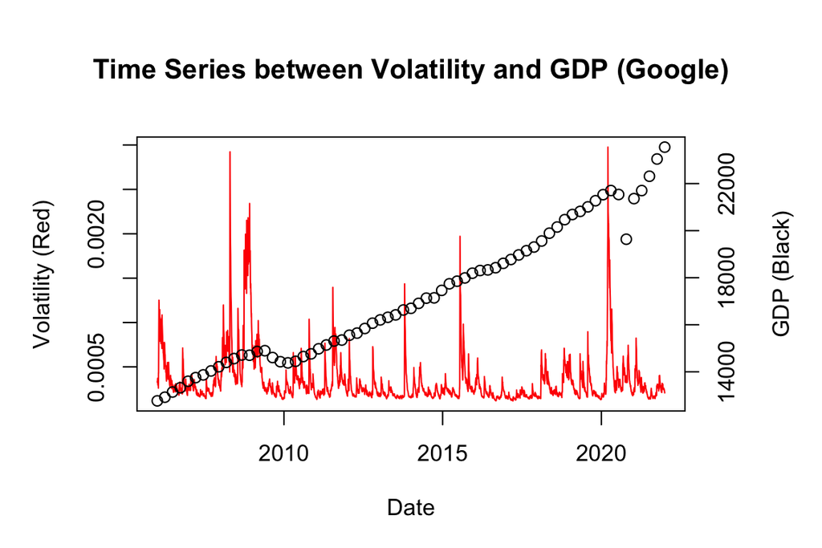

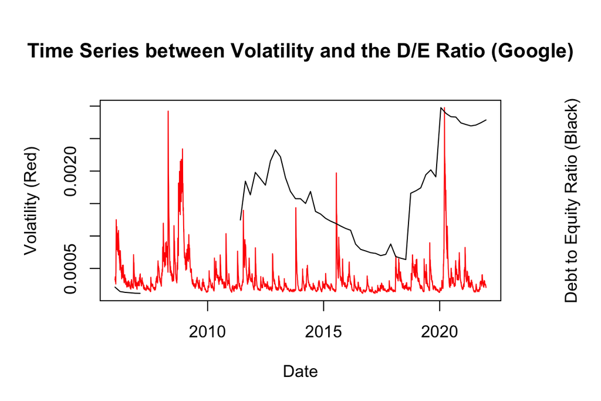

It should be noted that the total debt information was not available on Yahoo Finance during the 2007-2009 recession and some time after. This may be attributed to Google’s failure to report its total debt amount during that period, or a potential issue with gathering historical data.

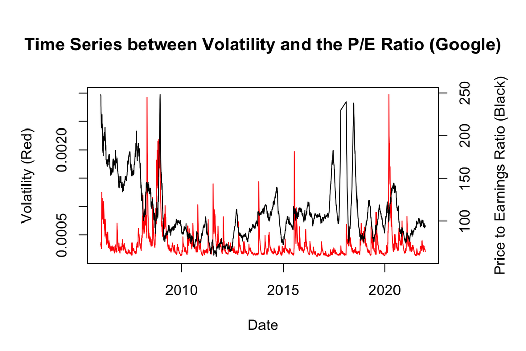

Although there was little change in the price to earnings ratio when volatility increased substantially during 2020, the general trend is similar to that of Apple.

# Questions: